# Luke larter homework 3

```r
library(tidyverse)
library(car)
```

```r
library(broom)
library(ggplot2)
library(infer)
```

#Challenge 1

```r
f <- "https://raw.githubusercontent.com/difiore/ada-2021-datasets/main/KamilarAndCooperData.csv"
d <- read_csv(f, col_names = TRUE)
d <- na.omit(d)
```

```r
mod=lm(WeaningAge_d~Brain_Size_Species_Mean, data=d)
summary(mod)
```

```
##
## Call:
## lm(formula = WeaningAge_d ~ Brain_Size_Species_Mean, data = d)
##
## Residuals:
##     Min      1Q  Median      3Q     Max
## -322.56 -130.81  -56.21  111.16  351.28
##
## Coefficients:
##                         Estimate Std. Error t value Pr(>|t|)
## (Intercept)             182.5688    51.6600   3.534  0.00187 **
## Brain_Size_Species_Mean   2.1622     0.3088   7.001 5.01e-07 ***
## ---
## Signif. codes:  0 '***' 0.001 '**' 0.01 '*' 0.05 '.' 0.1 ' ' 1
##
## Residual standard error: 180.7 on 22 degrees of freedom
## Multiple R-squared:  0.6902, Adjusted R-squared:  0.6761
## F-statistic: 49.02 on 1 and 22 DF,  p-value: 5.012e-07
```

```r
log_mod=lm(log(WeaningAge_d)~log(Brain_Size_Species_Mean), data=d)
summary(log_mod)
```

```
##
## Call:
## lm(formula = log(WeaningAge_d) ~ log(Brain_Size_Species_Mean),
##     data = d)
##
## Residuals:
##      Min       1Q   Median       3Q      Max
## -0.72943 -0.23154 -0.01903  0.27921  0.76209
##
## Coefficients:
##                              Estimate Std. Error t value Pr(>|t|)
## (Intercept)                   2.91298    0.36916   7.891 7.41e-08 ***
## log(Brain_Size_Species_Mean)  0.66994    0.08334   8.038 5.45e-08 ***
## ---
## Signif. codes:  0 '***' 0.001 '**' 0.01 '*' 0.05 '.' 0.1 ' ' 1
##
## Residual standard error: 0.4146 on 22 degrees of freedom
## Multiple R-squared:  0.746,  Adjusted R-squared:  0.7345
## F-statistic: 64.62 on 1 and 22 DF,  p-value: 5.451e-08
```

Regular model:

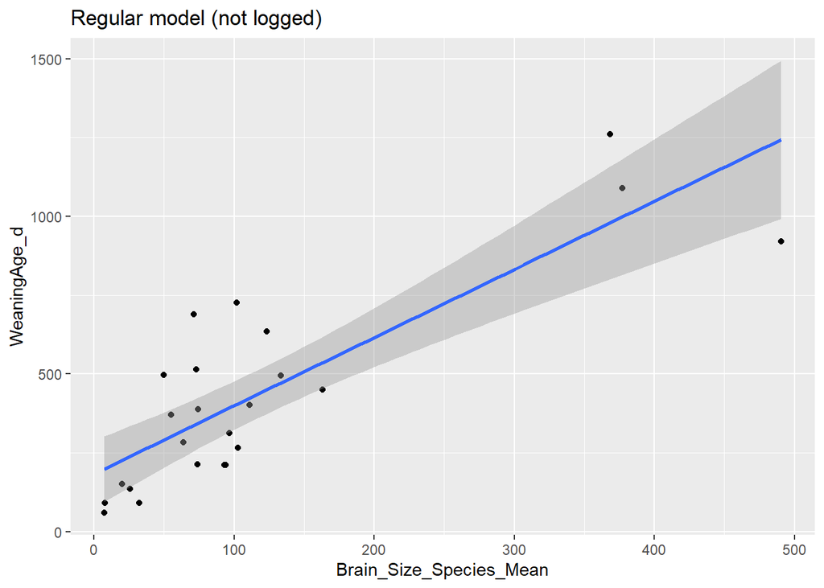

```r
g <- ggplot(data = d, aes(x = Brain_Size_Species_Mean, y = WeaningAge_d))
g <- g + geom_point()
g <- g + geom_smooth(method = "lm", formula = y ~ x) + ggtitle("Regular model (not logged)")
g
```

Log model:

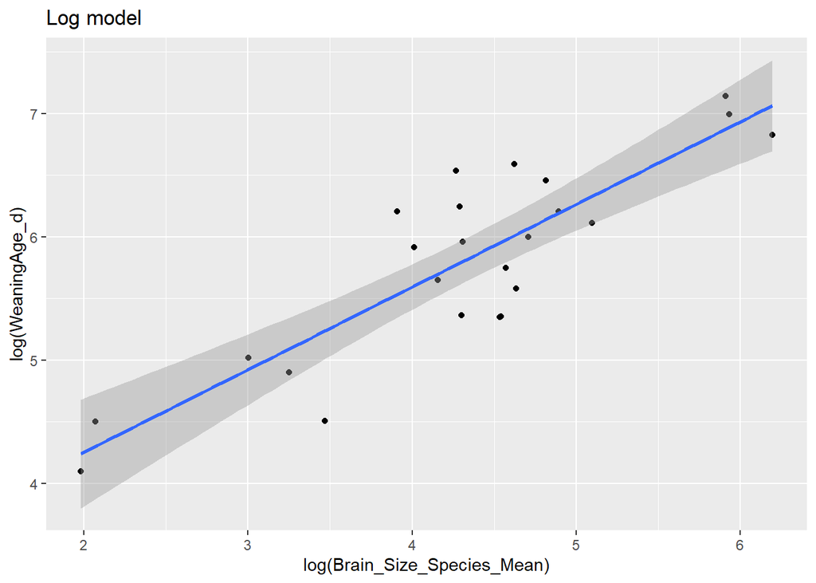

```r
gg <- ggplot(data = d, aes(x = log(Brain_Size_Species_Mean), y = log(WeaningAge_d)))
gg <- gg + geom_point()
gg <- gg + geom_smooth(method = "lm", formula = y ~ x) + ggtitle("Log model")
gg
```

The point estimate of the beta slope for the regular model is given in the model output as 2.16; this indicates that as the species mean brain size increases by 1 unit, weaning age increases by 2.16 units.

The point estimate of the beta slope for the log model is given in the model output as 0.67; this indicates that as the log of the species mean brain size increases by 1, the log of weaning age increases by 0.67.

The outcome of the tests associated with rejecting the null hypothesis that beta = 0 are the p values for the betas; they are less than out alpha threshold of 0.05, thus we can reject the null hypothesis and conclude there is a meaningful relationship between the variables.

Confidence intervals:

```r
CI_regular = tidy(mod, conf.int = TRUE, conf.level = 0.9)
CI_log = tidy(log_mod, conf.int = TRUE, conf.level = 0.9)

CI_regular
```

```
## # A tibble: 2 x 7
##   term                estimate std.error statistic    p.value conf.low conf.high
##   <chr>                  <dbl>     <dbl>     <dbl>      <dbl>    <dbl>     <dbl>
## 1 (Intercept)           183.      51.7        3.53    1.87e-3    93.9     271.
## 2 Brain_Size_Species~     2.16     0.309      7.00    5.01e-7     1.63      2.69
```

```r
CI_log
```

```
## # A tibble: 2 x 7
##   term                estimate std.error statistic    p.value conf.low conf.high
##   <chr>                  <dbl>     <dbl>     <dbl>      <dbl>    <dbl>     <dbl>
## 1 (Intercept)            2.91     0.369       7.89    7.41e-8    2.28      3.55
## 2 log(Brain_Size_Spe~    0.670    0.0833      8.04    5.45e-8    0.527     0.813
```

` PIs for regular model

```r
ci <- predict(mod,
  newdata = data.frame(Brain_Size_Species_Mean = d$Brain_Size_Species_Mean),
  interval = "confidence", level = 0.95
) # for a vector of values
ci <- data.frame(ci)
ci <- cbind(d$Brain_Size_Species_Mean, ci)
names(ci) <- c("weight", "c.fit", "c.lwr", "c.upr")

pi <- predict(mod,
  newdata = data.frame(Brain_Size_Species_Mean = d$Brain_Size_Species_Mean),
  interval = "prediction", level = 0.95
) # for a vector of values
pi <- data.frame(pi)
pi <- cbind(d$Brain_Size_Species_Mean, pi)
names(pi) <- c("weight", "p.fit", "p.lwr", "p.upr")
```

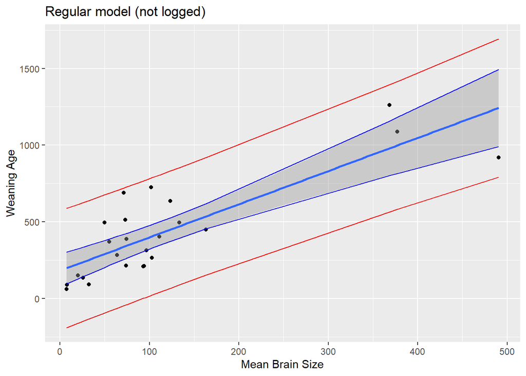

```r
g <- g + geom_line(
  data = ci, aes(x = weight, y = c.lwr),
  color = "blue"
)
g <- g + geom_line(
  data = ci, aes(x = weight, y = c.upr),
  color = "blue"
)

colors <- c("CI" = "blue", "PI" = "red")

g <- g + geom_line(data = pi, aes(x = weight, y = p.lwr), color = "red")
g <- g + geom_line(data = pi, aes(x = weight, y = p.upr), color = "red")
g = g + labs(x = "Mean Brain Size",
         y = "Weaning Age")
g
```

Prediction for species with brain size 750:

```r
new.data <- data.frame(
  Brain_Size_Species_Mean = 750)
predict(mod, newdata = new.data, interval = "confidence")
```

```
##        fit      lwr      upr
## 1 1804.184 1391.683 2216.684
```

We shouldn’t trust this results as it’s out of the range of the data our model was built with.

Which is better? In looking at the 2 original plots, we can see that the logged data represents a much more linear pattern than does the non-logged. The non-logged has stretched in the middle which have no data, whereas logging the variables causes the data to span more of the range of x values.

#Challenge 2

```r
mod2=lm(log(MeanGroupSize)~log(Body_mass_female_mean), data=d)
summary(mod2)
```

```
##
## Call:
## lm(formula = log(MeanGroupSize) ~ log(Body_mass_female_mean),
##     data = d)
##
## Residuals:
##      Min       1Q   Median       3Q      Max
## -2.03970 -0.57556  0.01865  0.59171  1.48135
##
## Coefficients:
##                            Estimate Std. Error t value Pr(>|t|)
## (Intercept)                  1.1426     1.4353   0.796    0.435
## log(Body_mass_female_mean)   0.1512     0.1637   0.923    0.366
##
## Residual standard error: 0.9815 on 22 degrees of freedom
## Multiple R-squared:  0.03731,    Adjusted R-squared:  -0.006447
## F-statistic: 0.8527 on 1 and 22 DF,  p-value: 0.3658
```

```r
#beta coefficients:
coef(mod2)
```

```
##                (Intercept) log(Body_mass_female_mean)
##                  1.1426138                  0.1512023
```

Get bootstrap distribution:

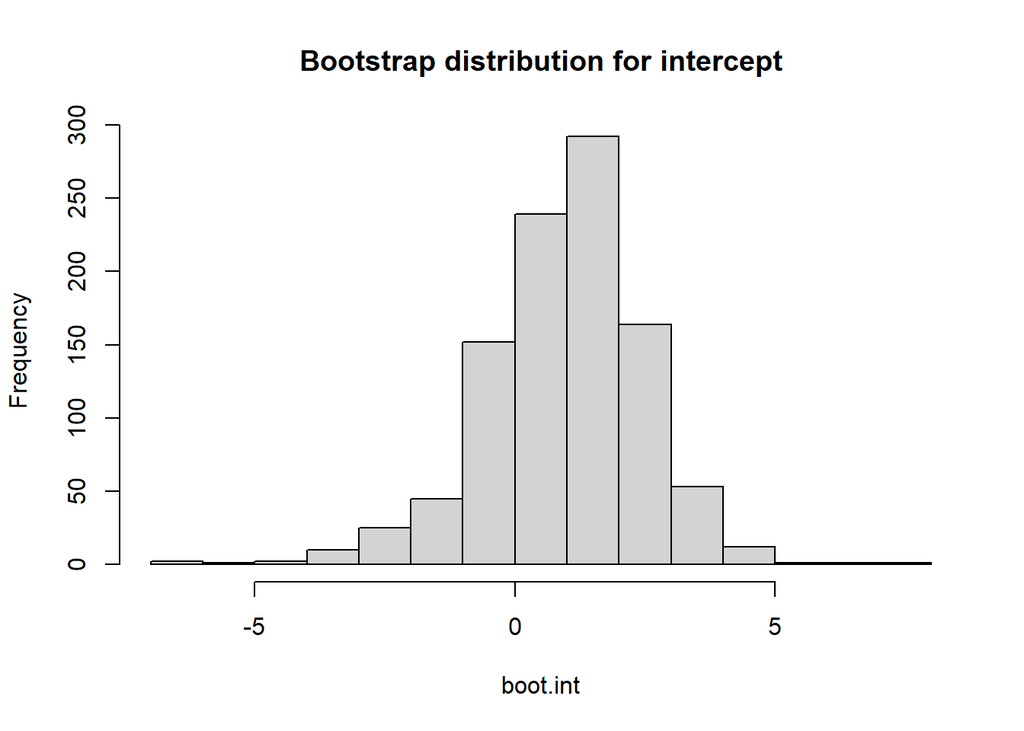

```r
reps=1000
boot.int=numeric(reps)
boot.coef=numeric(reps)

for (i in 1:reps){
  boot.dat=sample_n(d, nrow(d), replace=T)
  boot.mod=lm(log(MeanGroupSize)~log(Body_mass_female_mean), data=boot.dat)
  boot.int[i]=coef(boot.mod)[1]
  boot.coef[i]=coef(boot.mod)[2]
}

hist(boot.int, main="Bootstrap distribution for intercept")
```

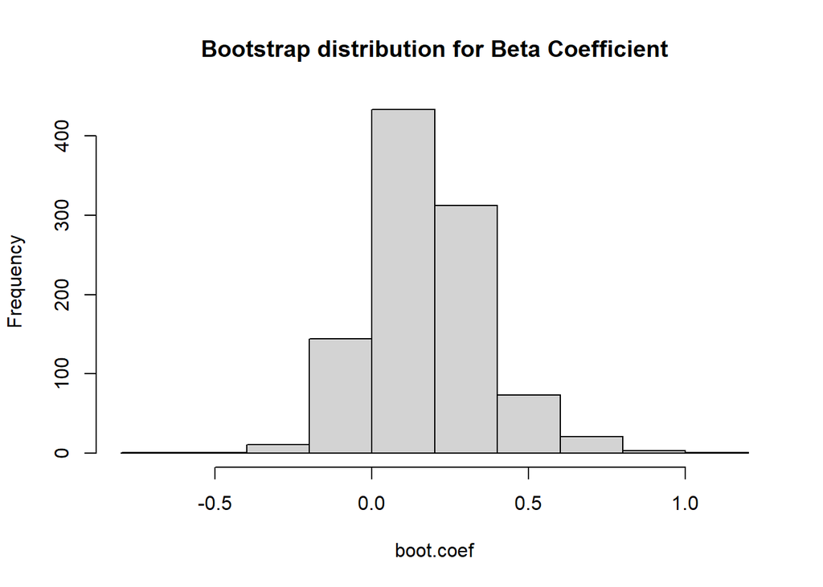

```r
hist(boot.coef, main="Bootstrap distribution for Beta Coefficient")
```

```r
#set parameters:
alpha <- 0.05
confidence_level <- 1 - alpha
p_lower <- alpha / 2
p_upper <- 1 - (alpha / 2)
degrees_of_freedom <- nrow(d) - 2
critical_value <- qt(p_upper, df = degrees_of_freedom)

SE.int=sd(boot.int) #get SE from sd of bootstrap distribution:
SE.coef=sd(boot.coef)

CI.lower.int = mean(boot.int) - SE.int * critical_value #calculate CIs:
CI.upper.int = mean(boot.int) + SE.int * critical_value

CI.lower.coef = mean(boot.coef) - SE.coef * critical_value
CI.upper.coef = mean(boot.coef) + SE.coef * critical_value

print(paste("As calculated from the bootstrap distribution, the SE for the intercept is ", SE.int, " and the SE for the beta coefficient is ", SE.coef))
```

```
## [1] "As calculated from the bootstrap distribution, the SE for the intercept is  1.53547917680878  and the SE for the beta coefficient is  0.183295119274837"
```

```r
print(paste("As calculated from the bootstrap distribution, the CI for the intercept is ", CI.lower.int, " to ", CI.upper.int," and the CI for the beta coefficient is ", CI.lower.coef, " to ", CI.upper.int))
```

```
## [1] "As calculated from the bootstrap distribution, the CI for the intercept is  -2.22950864749096  to  4.13926917473139  and the CI for the beta coefficient is  -0.205833655716714  to  4.13926917473139"
```

```r
summary(mod2)
```

```
##
## Call:
## lm(formula = log(MeanGroupSize) ~ log(Body_mass_female_mean),
##     data = d)
##
## Residuals:
##      Min       1Q   Median       3Q      Max
## -2.03970 -0.57556  0.01865  0.59171  1.48135
##
## Coefficients:
##                            Estimate Std. Error t value Pr(>|t|)
## (Intercept)                  1.1426     1.4353   0.796    0.435
## log(Body_mass_female_mean)   0.1512     0.1637   0.923    0.366
##
## Residual standard error: 0.9815 on 22 degrees of freedom
## Multiple R-squared:  0.03731,    Adjusted R-squared:  -0.006447
## F-statistic: 0.8527 on 1 and 22 DF,  p-value: 0.3658
```

```r
confint(mod2)
```

```
##                                2.5 %    97.5 %
## (Intercept)                -1.834085 4.1193127
## log(Body_mass_female_mean) -0.188385 0.4907895
```

#Challenge 3

```r
boot_lm=function(d, model, conf.level, reps.f){
  text=model
  model=lm(paste(text), data=d) #get model from string to actual model
  true.int=coef(model)[1] #get intercept, coefficient, SEs, and CIs from model output
  true.coef=coef(model)[2]
  true.SE.int=coef(summary(model))[, "Std. Error"][1]
  true.SE.coef=coef(summary(model))[, "Std. Error"][2]
  true.CI.lower.int=confint(model)[1,1]
  true.CI.upper.int=confint(model)[1,2]
  true.CI.lower.coef=confint(model)[2,1]
  true.CI.upper.coef=confint(model)[2,2]

  if (length(coef(model))==3){ #for your last model with 2 independet vars, these if statements will kick in
    true.coef3=coef(model)[3]
    true.SE.coef3=coef(summary(model))[, "Std. Error"][3]
    true.CI.lower.coef3=confint(model)[3,1]
    true.CI.upper.coef3=confint(model)[3,2]
  }

  boot.int.f=numeric(reps.f) #empty vectors to populate
  boot.coef.f=numeric(reps.f)
  boot.coef.f3=numeric(reps.f)

  for (i in 1:reps.f){ #loop through to get bootstrap distribution
    boot.dat.f=sample_n(d, nrow(d), replace=T) #resample each time
    boot.mod.f=lm(paste(text), data=boot.dat.f)
    boot.int.f[i]=coef(boot.mod.f)[1] #get model output and populate lists
    boot.coef.f[i]=coef(boot.mod.f)[2]

    if (length(coef(model))==3){
      boot.coef.f3[i]=coef(boot.mod.f)[3]
      }
  }

  alpha = 1-conf.level #set parameters to calculate bootstrap stats
  p = 1 - (alpha / 2)
  degrees_of_freedom <- nrow(d) - 2
  critical_value <- qt(p, df = degrees_of_freedom)

  SE.int.f=sd(boot.int.f) #calculate standard errors for bootstrap results
  SE.coef.f=sd(boot.coef.f)

  CI.lower.int.f = mean(boot.int.f) - SE.int.f * critical_value #calculate CIs for bootstrap results
  CI.upper.int.f = mean(boot.int.f) + SE.int.f * critical_value

  CI.lower.coef.f = mean(boot.coef.f) - SE.coef.f * critical_value
  CI.upper.coef.f = mean(boot.coef.f) + SE.coef.f * critical_value

  res.df=data.frame(calculated_by=c("lm", "bootstrap"), #put it all in a dataframe to be returned
                    intercept=c(true.int, mean(boot.int.f)),
                    coefficient=c(true.coef, mean(boot.coef.f)),
                    SE_intercept=c(true.SE.int, SE.int.f),
                    SE_coefficient=c(true.SE.coef, SE.coef.f),
                    intercept_CI_lower= c(true.CI.lower.int, CI.lower.int.f),
                    intercept_CI_upper= c(true.CI.upper.int, CI.upper.int.f),
                    coefficient_CI_lower= c(true.CI.lower.coef, CI.lower.coef.f),
                    coefficient_CI_upper= c(true.CI.upper.coef, CI.upper.coef.f))

   if (length(coef(model))==3){
      SE.coef.f3=sd(boot.coef.f3)
      CI.lower.coef.f3 = mean(boot.coef.f3) - SE.coef.f3 * critical_value
      CI.upper.coef.f3 = mean(boot.coef.f3) + SE.coef.f3 * critical_value
      c3=data.frame(coefficient3=c(true.coef3, mean(boot.coef.f3)),
                    SE_coefficient3=c(true.SE.coef3, SE.coef.f3),
                    coefficient_CI_lower3= c(true.CI.lower.coef3, CI.lower.coef.f3),
                    coefficient_CI_upper3= c(true.CI.upper.coef3, CI.upper.coef.f3))
      res.df=cbind(res.df,c3)
      }

  return(res.df)

}
```

```r
print(boot_lm(d,"log(MeanGroupSize)~log(Body_mass_female_mean)",0.95,1000))
```

```
##             calculated_by intercept coefficient SE_intercept SE_coefficient
## (Intercept)            lm  1.142614   0.1512023     1.435333      0.1637454
##                 bootstrap  1.045813   0.1627793     1.663087      0.1977620
##             intercept_CI_lower intercept_CI_upper coefficient_CI_lower
## (Intercept)          -1.834085           4.119313           -0.1883850
##                      -2.403219           4.494845           -0.2473541
##             coefficient_CI_upper
## (Intercept)            0.4907895
##                        0.5729126
```

```r
print(boot_lm(d,"log(DayLength_km) ~ log(Body_mass_female_mean)",0.95,1000))
```

```
##             calculated_by  intercept coefficient SE_intercept SE_coefficient
## (Intercept)            lm -0.3925435  0.04843659     1.053627      0.1201997
##                 bootstrap -0.4456979  0.05384586     1.025430      0.1235468
##             intercept_CI_lower intercept_CI_upper coefficient_CI_lower
## (Intercept)          -2.577633           1.792546           -0.2008424
##                      -2.572311           1.680915           -0.2023745
##             coefficient_CI_upper
## (Intercept)            0.2977156
##                        0.3100662
```

```r
print(boot_lm(d,"log(DayLength_km) ~ log(Body_mass_female_mean) + log(MeanGroupSize)",0.95,1000))
```

```
##             calculated_by  intercept coefficient SE_intercept SE_coefficient
## (Intercept)            lm -0.7355628 0.003044782    0.9981878     0.11442456
##                 bootstrap -0.7960299 0.010838512    0.9493878     0.09388634
##             intercept_CI_lower intercept_CI_upper coefficient_CI_lower
## (Intercept)          -2.811408           1.340282           -0.2349141
##                      -2.764940           1.172880           -0.1838698
##             coefficient_CI_upper coefficient3 SE_coefficient3
## (Intercept)            0.2410037    0.3002059       0.1461779
##                        0.2055469    0.2888416       0.1556407
##             coefficient_CI_lower3 coefficient_CI_upper3
## (Intercept)          -0.003787651             0.6041994
##                      -0.033937571             0.6116207
```

Coefficients etc. from lm and bootstrap are pretty close for all variables!